# Homework 2 By: Adham Suliman

1.1 Use runif()

```r
library("random")
set.seed(15)
Sample<-runif(1000,0,1)
```

1.2 Simulate uniform random sample on [0,1] Using random.org

```r
suppressWarnings(library(random))
nFlips<-1000
dataFromRandom<-randomNumbers(n=nFlips, min=0, max=1, col=1, base=2, check=TRUE)
head(dataFromRandom)
```

```
##      V1
## [1,]  1
## [2,]  1
## [3,]  1
## [4,]  1
## [5,]  0
## [6,]  0
```

1.3 Downloading data from Random.org

```r
dataFromRandom<-read.table(paste("C:/Users/u353822/Documents/R/Statistical Analysis","randbyte.txt",sep="/"))
dataFromRandom<-na.omit(unname(unlist(dataFromRandom)))
dataFromRandom<-(as.vector(sapply(dataFromRandom,function(z) head(intToBits(z),8)))==1)*1
head(dataFromRandom)
```

```
## [1] 1 1 1 0 0 1
```

1.4 Turning binary sequence to uniform random numbers

```r
set.seed(15)
bitsToInt<-function(x) {
  packBits(rev(c(rep(FALSE, 32-length(x)%%32), as.logical(x))), "integer")
}
bitsToInt(c(1,1,1,1,1,0))
```

```
## [1] 62
```

```r
Binary.matrix<-matrix(dataFromRandom,ncol=10)
head(Binary.matrix)
```

```
##      [,1] [,2] [,3] [,4] [,5] [,6] [,7] [,8] [,9] [,10]
## [1,]    1    0    0    0    0    0    0    0    0     0
## [2,]    1    0    1    0    0    0    1    0    1     0
## [3,]    1    0    0    0    1    1    1    1    1     1
## [4,]    0    1    1    1    1    0    0    0    1     0
## [5,]    0    0    1    0    1    0    1    1    1     1
## [6,]    1    1    0    0    0    0    0    1    0     1
```

```r
dataFromRandom.dec<-apply(Binary.matrix,1,bitsToInt)/2^10
head(dataFromRandom.dec)
```

```
## [1] 0.5000000 0.6347656 0.5615234 0.4707031 0.1708984 0.7548828
```

2.1 Test uniformity of distribution of both random number generators.

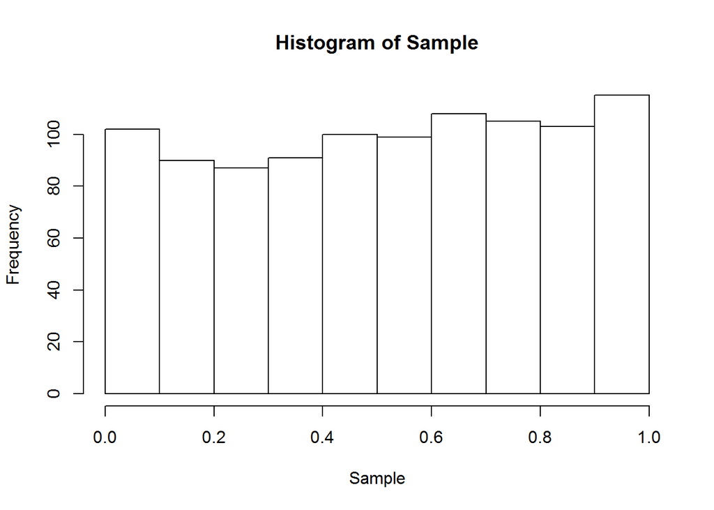

```r
library("random")
set.seed(15)
Sample<-runif(1000,0,1)
Sample.histogram<-hist(Sample)
```

```r
Sample.histogram
```

```
## $breaks
##  [1] 0.0 0.1 0.2 0.3 0.4 0.5 0.6 0.7 0.8 0.9 1.0
##
## $counts
##  [1] 102  90  87  91 100  99 108 105 103 115
##
## $density
##  [1] 1.02 0.90 0.87 0.91 1.00 0.99 1.08 1.05 1.03 1.15
##
## $mids
##  [1] 0.05 0.15 0.25 0.35 0.45 0.55 0.65 0.75 0.85 0.95
##
## $xname
## [1] "Sample"
##
## $equidist
## [1] TRUE
##
## attr(,"class")
## [1] "histogram"
```

What does the histogram tell you about the distribution? Is it consistent with the goal of simulation? The histogram seems to have a relatively equal distribution except from .3 to 1 where there seems to be a slight positive increase in frequencies. Other than that, it is consistent with the goal of this simulation.

Estimate mean and standard deviation of Sample.histogram$density.

```r
(Sample.histogram.mean<-mean(Sample.histogram$density))
```

```
## [1] 1
```

```r
(Sample.histogram.sd<-sd(Sample.histogram$density))
```

```
## [1] 0.08679478
```

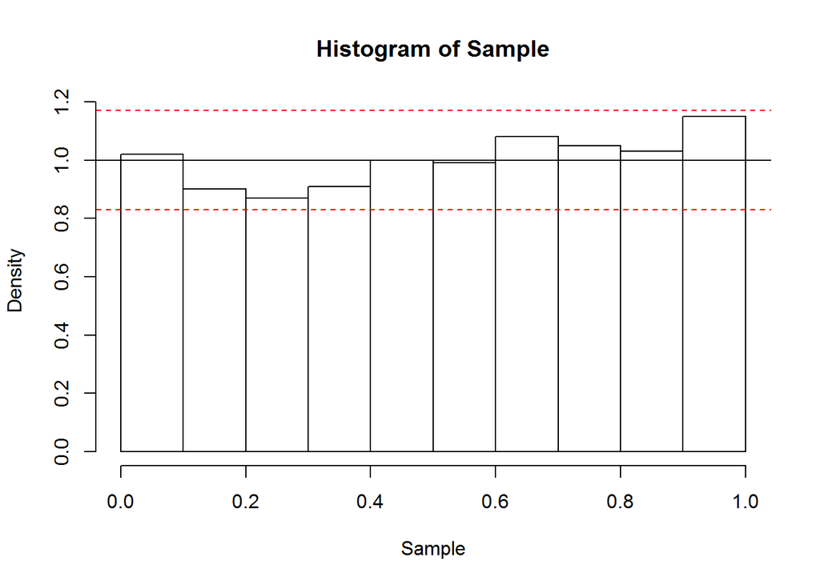

```r
plot(Sample.histogram,freq=FALSE,ylim=c(0,Sample.histogram.mean+2*Sample.histogram.sd))
abline(h=Sample.histogram.mean)
abline(h=Sample.histogram.mean+1.96*Sample.histogram.sd,col="red",lty=2)
abline(h=Sample.histogram.mean-1.96*Sample.histogram.sd,col="red",lty=2)
```

What does the graph tell you about the observed distribution? This Graph tells me that the distribution is random because we fail to reject the null that it is random. The area between the red lines represents 95% of the normal distribution for randomness and all the data falls in between these two lines.

Estimate moments of Sample

```r
(Sample.mean<-mean(Sample))
```

```
## [1] 0.5161848
```

```r
(Sample.variance<-var(Sample))
```

```
## [1] 0.08413663
```

What do you conclude about the estimated distribution from the moments? I would conclude that it is randomly distriubted due to the min, 1st quartile, mean, 3rd quartile, and max respectively falling nearly on 0,.25,.5,.75,1 which shows a random distribution from 0 to 1.